# Capstone Exploratory Analysis

Sergey Polgul

Saturday, November 15, 2014

The purpose of this document id to conduct exploratory data analysis for the SfitKey assignment. We will proceed with loading th data. We will split the data set into training and testing to see how our model generalizes.

For the purpose of the assignment we will only work with twitter data set. I will clarify this point further into the project but it sems that twitter data set is the one that would be most representative for the mobile phone keyboard.

The Twitter dataset contains of 320 MB of twitts 1 that ammounts to over of 1.4 mil messages.

We are using 0.5 million messages for the exploratory analysis taken from the training data set.

```r
sdir = "D:/oradata//datasets/SwiftKey/"
twitter.all <- readLines(paste0(sdir, 'en_US.twitter.txt'), encoding="UTF-8")
Encoding(twitter.all) <- "UTF-8"
twitter.all <-iconv(twitter.all, "UTF-8", "ASCII",sub='')
n.twitter = length(twitter.all)
set.seed(1744)
train = sample(1:n.twitter, size = floor(.6 * n.twitter))
expl  = sample(train, size=5e5)

twitter.expl = twitter.all[expl]
```

Following code loads the text into the corous data structure of the tm package. We are converting text into ASCII encoding, transforming the text into all lower case letters, removing obscene wordse and stem document.

```r
library(tm)
library(SnowballC)
#require(doParallel)
#cl <- makeCluster(detectCores())
#registerDoParallel(cl)
source("lib//swear.R")

corpus = Corpus(VectorSource(twitter.expl), readerControl = list(language="english"))
corpus=tm_map(corpus, content_transformer(tolower))
corpus=tm_map(corpus, removeWords,  c(stopwords("english"), swear))
corpus = tm_map(corpus, removePunctuation)
corpus = tm_map(corpus, stripWhitespace)
corpus = tm_map(corpus, stemDocument)
```

Building the corpus is the most memory intensive step in our process however it allows for routines in tm package to preprocess and summarize data set for us.

Follwowing building the corpus we examine most frequently used words. It is obvious that for us to be able to predict the next word it should be frequent in the corpus.

```r
#  dtm <- DocumentTermMatrix(corpus,
#                  control=list(wordLengths=c(1, Inf),
#                  bounds=list(global=c(floor(length(corpus$content)*0.01), Inf))))
#
#
#  dtm10 <- DocumentTermMatrix(corpus,
#                  control=list(wordLengths=c(1, Inf),
#                  bounds=list(global=c(floor(length(corpus$content)*0.001), Inf))))

 dtm100 <- DocumentTermMatrix(corpus,
                 control=list(wordLengths=c(1, Inf),
                 bounds=list(global=c(floor(length(corpus$content)*0.0001), Inf))))
```

Now Lets compute Bi and Tri-grams or that words that mos commonly go together. Build Document term Matrix and computing Bi to Quad-grams. see http://tm.r-forge.r-project.org/faq.html.

To limit space used during this process we will limit ngrams recorded only if their frequency is greater than 0.01% across all twitter messages.

```r
library(RWeka)
library(tm)
library(SnowballC)
Sys.setenv(JAVA_HOME='C:\\ORACLE\\product\\12.1.0\\dbhome_2\\jdk\\jre')
library (rJava)

options(mc.cores=1)
# http://stackoverflow.com/questions/19024873/why-does-r-hang-when-using-ngramtokenizer?rq=1
BigramTokenizer <- function(x) NGramTokenizer(x, Weka_control(min = 2, max = 4))

# nGram <- TermDocumentMatrix(corpus,
#                             control = list(tokenize = BigramTokenizer)
#                             #bounds=list(global=c(floor(length(corpus$content)*0.0001), Inf))
#         )

NGram  <- DocumentTermMatrix(corpus,
                 control=
        list(   wordLengths=c(1, Inf),
                        bounds=list(global=c(floor(length(corpus$content)*0.0001), Inf)),
                tokenize = BigramTokenizer
            )
        )
```

Lets summarize our word and N-Gram frequency tables. We will be using these data structures in the predictive modeling.

```r
source('lib//db_summarize_words.R')

source('lib//dd_summarize_ngrams.R')

wsum[,Frequency:=N/5e5]
```

```
##          word     N Frequency
##   1:        s 33422  0.066844
##   2:     just 31052  0.062104
##   3:      get 29253  0.058506
##   4:    thank 27135  0.054270
##   5:        m 26346  0.052692
##   6:     like 26018  0.052036
##   7:       go 25664  0.051328
##   8:     love 24276  0.048552
##   9:      day 21367  0.042734
##  10:     good 20714  0.041428
##  11:     will 19193  0.038386
##  12:      can 18127  0.036254
##  13:       rt 17972  0.035944
##  14:     know 17400  0.034800
```

[output cut: 87 more lines]

```r
ngsum[,Frequency:=N/5e5]
```

```
##                 ngram    N Frequency
##   1:        right now 3470  0.006940
##   2:       last night 2509  0.005018
##   3:     look forward 2354  0.004708
##   4:        look like 2234  0.004468
##   5:        feel like 1857  0.003714
##   6:     thank follow 1669  0.003338
##   7:         just got 1474  0.002948
##   8:             m go 1367  0.002734
##   9:         let know 1245  0.002490
##  10:   happi birthday 1184  0.002368
##  11:        good morn 1180  0.002360
##  12:          can get 1134  0.002268
##  13:        good luck 1082  0.002164
##  14:        next week 1072  0.002144
```

[output cut: 87 more lines]

```r
wsum$word= factor(wsum$word, levels=wsum$word)
ngsum$ngram = factor(ngsum$ngram, levels=ngsum$ngram)
```

Lets plot frequencies of occurances of words

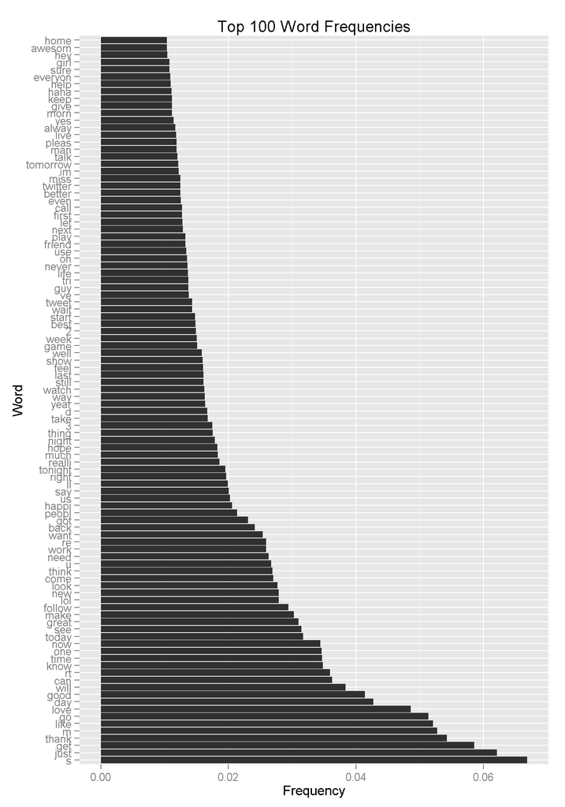

```r
library(ggplot2)


fw = factor()
wrdFreq <- ggplot(data=wsum, aes(x=word, y=Frequency)) +
  geom_bar(stat="identity") +
  labs(x="Word", y="Frequency", title="Top 100 Word Frequencies") +
  coord_flip()

print(wrdFreq)
```

A Plot of Top 100 N-Grams

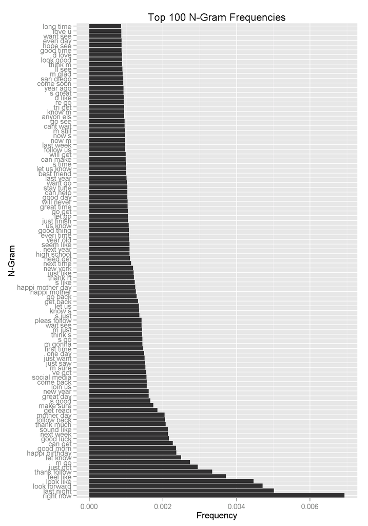

```r
library(ggplot2)


fw = factor()
ngrmFreq <- ggplot(data=ngsum, aes(x=ngram, y=Frequency)) +
  geom_bar(stat="identity") +
  labs(x="N-Gram", y="Frequency", title="Top 100 N-Gram Frequencies") +
  coord_flip()

print(ngrmFreq)
```